# Species Sensitivity Distribution (SSD) Construction for Microcystins in California Freshwater Aquatic Species

EPA (1985) Guidelines methodology

Author

SCCWRP, Leah Thornton Hampton

Published

October 23, 2026

## Overview

This document constructs Species Sensitivity Distributions (SSDs) for microcystin toxicity data (`ToxSummary.csv`) using the `ssdtools` R package. An SSD describes the variation in sensitivity across species by fitting a statistical distribution — here a log-normal — to single per-species toxicity values, then reading the 5th percentile (HC5) as the concentration protective of 95% of species.

Four species-scope variants are presented:

| Section | Filter | Rationale |
| --- | --- | --- |
| All Species | none | broadest possible dataset |
| California Relevant | `ca_relevant == "Yes"` | species judged relevant to California conditions (residents + common non-native test species) |
| California Residents | `ca_resident == "Yes"` | species with established populations in California |
| California Native Genus | `ca_native_genus == "Yes"` | species whose genus is native to California, even if the tested species itself is not |

## Setup

```r
library(tidyverse)
library(ssdtools)
library(ggplot2)

zissou1_extended <- c(
  "Salmonid"                     = "#1c1c84",
  "Second Fish Family"           = "#3B9AB2",
  "Chordata"                     = "#78B7C5",
  "Planktonic Crustacean"        = "#EBCC2A",
  "Benthic Crustacean"           = "#E1AF00",
  "Insect"                       = "#e86e0b",
  "Other Phylum"                 = "#F21A00",
  "Rotifera, Annelida, Mollusca" = "#701705")
```

The `zissou1_extended` palette maps one color to each of the eight taxonomic groups, keyed by group name so each group gets the same color across all plots.

## Data Import and Preparation

```r
#import
tox_dat <- read.csv(file = "Data/ToxSummary.csv")


#tidy
tox_dat_tidy <- tox_dat %>%
  #convert loec to noec by dividing by 2 if there is no noec, otherwise use noec
  mutate(noec_ssd = case_when(
    !is.na(noec_ug_l) ~ noec_ug_l,
    is.na(noec_ug_l) & !is.na(loec_ug_l) ~ loec_ug_l/2
  )) %>%
  #if acute exposure duration, divide the noec by 10, otherwise leave it along
  mutate(noec_ssd = if_else(chronic_acute == "acute", noec_ssd/10, noec_ssd)) %>%
  #include only higher level endpoints
  filter(endpoint %in% c("Growth", "Development", "Reproduction", "Mortality", "Growth + Development")) %>%
  #mark invasive species
  mutate(Species = if_else(note == "Invasive", paste0(Species, "*"), Species))
```

Invasive species are flagged with an asterisk in the `Species` label so they are visually distinguishable on the SSD plots without being excluded from the fit. Whether to exclude invasives from a regulatory SSD is a policy decision not resolved here.

## SSD Plots

Each plot section below follows the same workflow: filter to the target species scope → collapse to one median NOEC per species → fit a log-normal distribution via `ssd_fit_dists()` → generate predicted percentiles with confidence intervals via `predict()` → plot.

### All Species

The “kitchen sink” variant uses the full endpoint-filtered dataset with no geographic scope restriction. It represents the most data-rich SSD and serves as a baseline for comparing how restricting scope shifts the distribution.

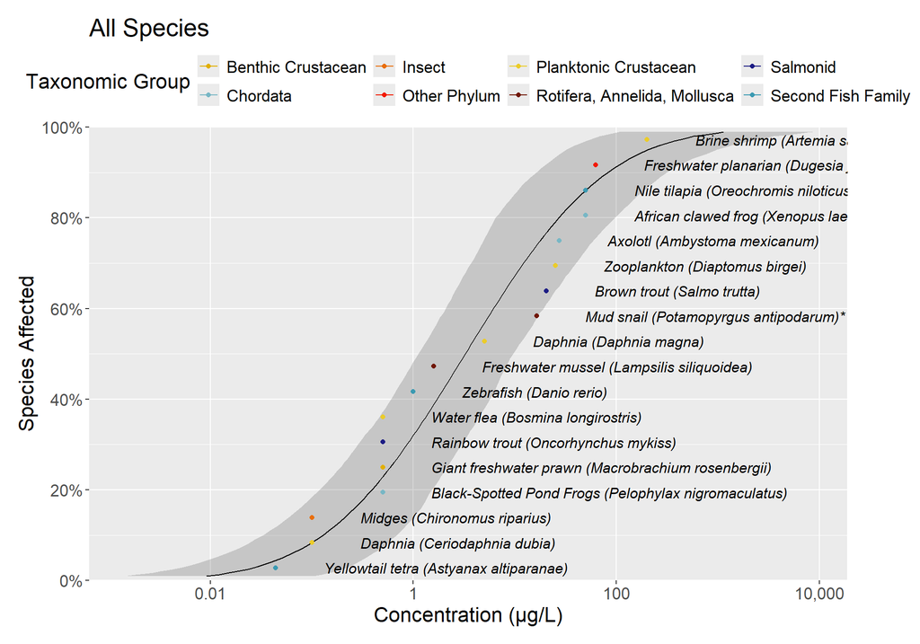

```r
#kitchen sink
fit_dat <- tox_dat_tidy %>%
    filter(!is.na(noec_ssd)) %>%
    group_by(Species) %>%
    mutate(Conc = median(noec_ssd)) %>% #collapse NOEC by species
    ungroup() %>%
    group_by(Species, Conc, group) %>%
    summarise()

ssd_fits <- ssd_fit_dists(fit_dat, dists = "lnorm")

ssd_pred <- predict(ssd_fits, ci = TRUE)

ssd_plot(fit_dat, ssd_pred,
  label = "Species",
  color = "group",
  xlab = "Concentration (µg/L)",
  ribbon = TRUE,
  label_size = 4,
  hc = NULL
) +
  expand_limits(x = 3000) +
  scale_color_manual(values = zissou1_extended) +
  labs(title = "All Species", color = "Taxonomic Group") +
  theme(text = element_text(size = 16), legend.position = "top",
        plot.margin = margin(0.5, 2, 0.5, 0.5, "cm"))
```

### California Relevant Species

This variant applies the `ca_relevant == "Yes"` filter, which retains species judged relevant to California aquatic environments — including both residents and widely used non-native test species (e.g., standard lab strains). This is the scope most comparable to the CCC derivation in `CCC.qmd`, which uses the same `ca_relevant` flag.

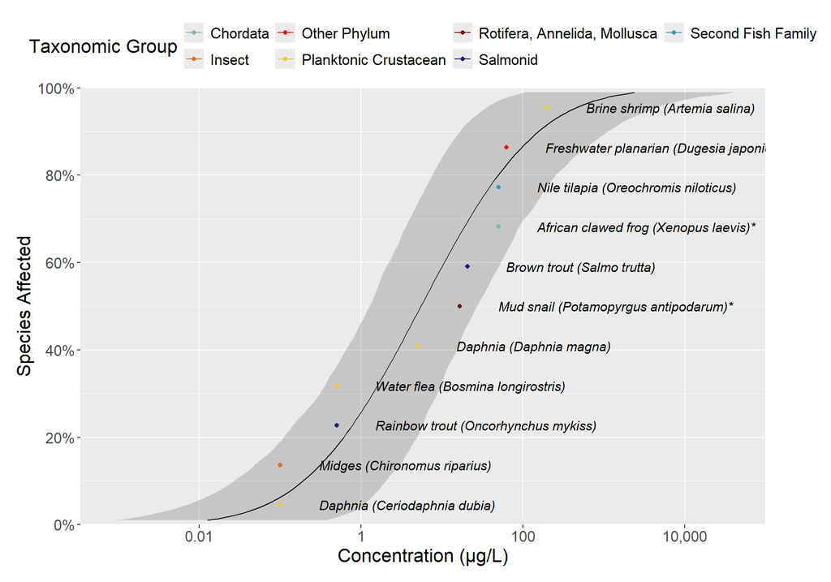

```r
#cali relevant
fit_dat <- tox_dat_tidy %>%
    filter(
      ca_relevant == "Yes",
      !is.na(noec_ssd)) %>%
    group_by(Species) %>%
    mutate(Conc = median(noec_ssd)) %>% #collapse NOEC by species
    ungroup() %>%
    group_by(Species, Conc, group) %>%
    summarise()

ssd_fits <- ssd_fit_dists(fit_dat, dists = "lnorm")

ssd_pred <- predict(ssd_fits, ci = TRUE)

ssd_plot(fit_dat, ssd_pred,
  label = "Species",
  color = "group",
  xlab = "Concentration (µg/L)",
  ribbon = TRUE,
  label_size = 4,
  hc = NULL
) +
  expand_limits(x = 3000) +
  scale_color_manual(values = zissou1_extended) +
  labs(color = "Taxonomic Group") +
  theme(text = element_text(size = 16), legend.position = "top",
        plot.margin = margin(0.5, 2, 0.5, 0.5, "cm"))
```

### California Residents

The `ca_resident == "Yes"` filter is more restrictive than `ca_relevant`, retaining only species with established populations in California. Removing non-native lab strains typically reduces the species count and may shift the distribution if those strains were among the more or less sensitive entries.

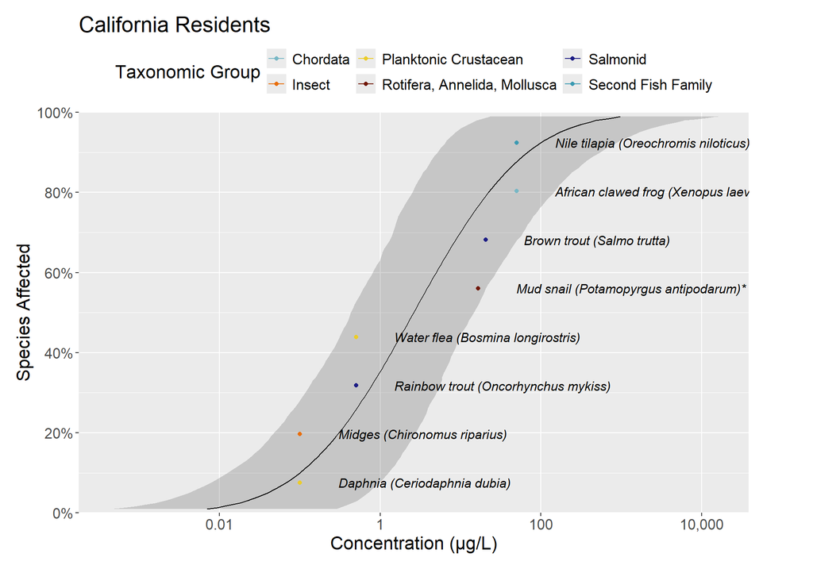

```r
#cali residents
fit_dat <- tox_dat_tidy %>%
    filter(
      ca_resident == "Yes",
      !is.na(noec_ssd)) %>%
    group_by(Species) %>%
    mutate(Conc = median(noec_ssd)) %>% #collapse NOEC by species
    ungroup() %>%
    group_by(Species, Conc, group) %>%
    summarise()

ssd_fits <- ssd_fit_dists(fit_dat, dists = "lnorm")

ssd_pred <- predict(ssd_fits, ci = TRUE)

ssd_plot(fit_dat, ssd_pred,
  label = "Species",
  color = "group",
  xlab = "Concentration (µg/L)",
  ribbon = TRUE,
  label_size = 4,
  hc = NULL
) +
  expand_limits(x = 3000) +
  scale_color_manual(values = zissou1_extended) +
  labs(title = "California Residents", color = "Taxonomic Group") +
  theme(text = element_text(size = 16), legend.position = "top",
        plot.margin = margin(0.5, 2, 0.5, 0.5, "cm"))
```

### California Native Genus

The `ca_native_genus == "Yes"` filter includes species whose **genus** is native to California, even if the specific test strain or congener tested is not strictly native. This is a pragmatic expansion of the native-only scope that recovers test data from closely related taxa when direct native-species data are scarce.

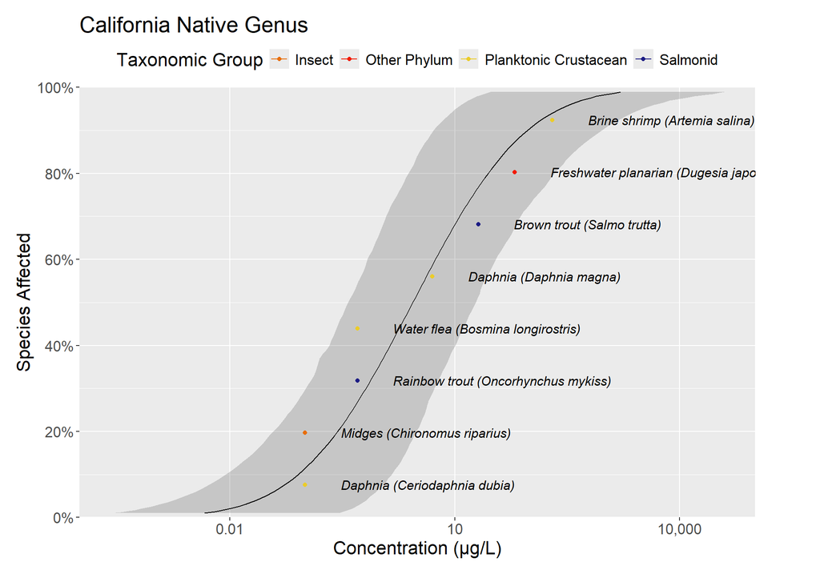

```r
#cali native genus
fit_dat <- tox_dat_tidy %>%
    filter(
      ca_native_genus == "Yes",
      !is.na(noec_ssd)) %>%
    group_by(Species) %>%
    mutate(Conc = median(noec_ssd)) %>% #collapse NOEC by species
    ungroup() %>%
    group_by(Species, Conc, group) %>%
    summarise()

ssd_fits <- ssd_fit_dists(fit_dat, dists = "lnorm")

ssd_pred <- predict(ssd_fits, ci = TRUE)

ssd_plot(fit_dat, ssd_pred,
  label = "Species",
  color = "group",
  xlab = "Concentration (µg/L)",
  ribbon = TRUE,
  label_size = 4,
  hc = NULL
) +
  expand_limits(x = 3000) +
  scale_color_manual(values = zissou1_extended) +
  labs(title = "California Native Genus", color = "Taxonomic Group") +
  theme(text = element_text(size = 16), legend.position = "top",
        plot.margin = margin(0.5, 2, 0.5, 0.5, "cm"))
```

## Limitations

- **LOEC/2 substitution introduces directional uncertainty.** Using half the LOEC as a NOEC surrogate assumes the true NOEC lies halfway between zero effect and the first observed effect concentration — a reasonable default but one that understates sensitivity for species where the true NOEC is close to zero, and overstates it where the dose-response is very steep.
- **Fixed ACR of 10 may not reflect species-specific ratios.** The acute-to-chronic conversion factor varies widely across taxa and compounds. Using a fixed value of 10 introduces uncertainty into the chronic-equivalent concentrations derived from acute tests.
- **Log-normal is assumed, not tested.** A single distribution family (`lnorm`) is fitted here. Comparing fit across multiple candidate distributions (log-logistic, gamma, Weibull) and selecting based on AIC or goodness-of-fit is standard SSD practice but is not performed in this document.
- **Per-species medians suppress within-species variability.** Collapsing multiple tests per species to a single median discards information about life-stage and laboratory variation. A species represented by many tests under very different conditions may have a median that does not accurately represent any one condition.
- **HC5 confidence intervals widen substantially at small N.** The California native genus and residents variants include relatively few species, so the confidence ribbon around the fitted curve is correspondingly wide. The HC5 point estimate should be interpreted with caution in those variants.
- **Invasive species are retained in the fit.** Asterisked species are visually flagged but not excluded. A regulatory SSD intended to protect native communities would typically exclude invasives from the fit, not merely label them.

End of Analysis.